# Exploratory Data Analysis

## How “strong” is the covariation? - 1

Patterns in your data provide clues about relationships. If a systematic relationship exists between two variables it will appear as a pattern in the data. If you spot a pattern, ask yourself:

- Could this pattern be due to coincidence (i.e. random chance)?
- How can you describe the relationship implied by the pattern?
- How strong is the relationship implied by the pattern?
- What other variables might affect the relationship?
- Does the relationship change if you look at individual subgroups of the data?

One way to answer these questions is assess how “strong” is the covariation between the evaluated variables. A correlation coefficient is the statistical measure of covariation. It expresses the extent to which two variables are linearly related (meaning they change together at a constant rate). Correlation coefficients are a common tool for describing simple relationships without making a statement about cause and effect. They do so by quantifying the strength of the linear relationship between two variables.

The correlation coefficient is a unit-free value between -1 and 1. Statistical significance is indicated with a p-value. Therefore, correlations are typically written with two key numbers: *Value* and *Significance*.

You need to know that monotonic relationships are those where the variables tend to move in the same/opposite direction but not necessarily at a constant rate, whereas the rate is constant in a linear relationship.

**Your task:**

Based on the data stored in the object `green` you will:

- Assess the correlation between total biomass (y-axis) per site and burrows density (x-axis) for the `DS` site.
- How strong is the relation between total biomass and burrows density changes for each site?

```r
# create an object with the observations for Drumsite
greenDS <- green[green$SITE == "DS", ]

# Step 1. Test for assumptions of correlation, here two assumptions are checked which need to be fulfilled before performing the correlation.
# Shapiro test, which is test to check the input variable is following the normal distribution or not, is used to check whether the variables to be assessed  are  normally distributed or not.
shapiro.test(greenDS$TOTMASS) # assess normality for TOTMASS
```

```
##
##  Shapiro-Wilk normality test
##
## data:  greenDS$TOTMASS
## W = 0.88415, p-value = 0.2063
```

```r
shapiro.test(greenDS$BURROWS) # assess normality for BURROWS
```

```
##
##  Shapiro-Wilk normality test
##
## data:  greenDS$BURROWS
## W = 0.84621, p-value = 0.08718
```

```r
# Are the variables normally distributed?
## p–value is greater than 0.05, so we can assume the normality. Why? because the null-hypothesis tested is if the observed distribution is the same as normal; and if they are the same should be p–value is greater than 0.05.

# Step 2 Estimate the Pearson and Spearman correlations

## Pearson Correlation
cor(
  x = greenDS$BURROWS, # Sets the x-axes range of values
  y = greenDS$TOTMASS, # Sets the y-axes range of values
  method = "pearson"
) # Sets the correlation coefficient to use
```

```
## [1] 0.3917155
```

```r
## Spearman Correlation
cor(
  x = greenDS$BURROWS, # Sets the x-axes range of values
  y = greenDS$TOTMASS, # Sets the y-axes range of values
  method = "spearman"
) # Sets the correlation coefficient to use
```

```
## [1] 0.1676677
```

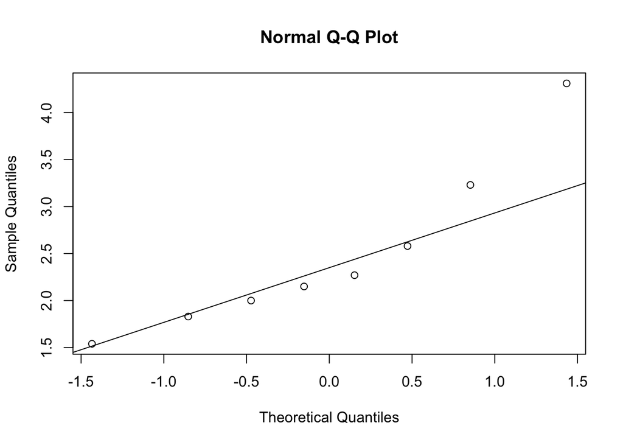

```r
# Based on the normality test which correlation coefficient you should use?
## As both BURROWS and TOTMASS are normal for the Drum site Person corrections can be used.

# Another way to assess for normality are qqplots. Here, you compare the observed quantiles tho those of a theoretical normal distribution. If the values fall in a straight line you could say that the values are normal. This is a more subjective way to assess normality.

# qqplots for TOTMASS
qqnorm(greenDS$TOTMASS) # assess observed/theoretical quantities for BURROWS
qqline(greenDS$TOTMASS) # add the trend line
```

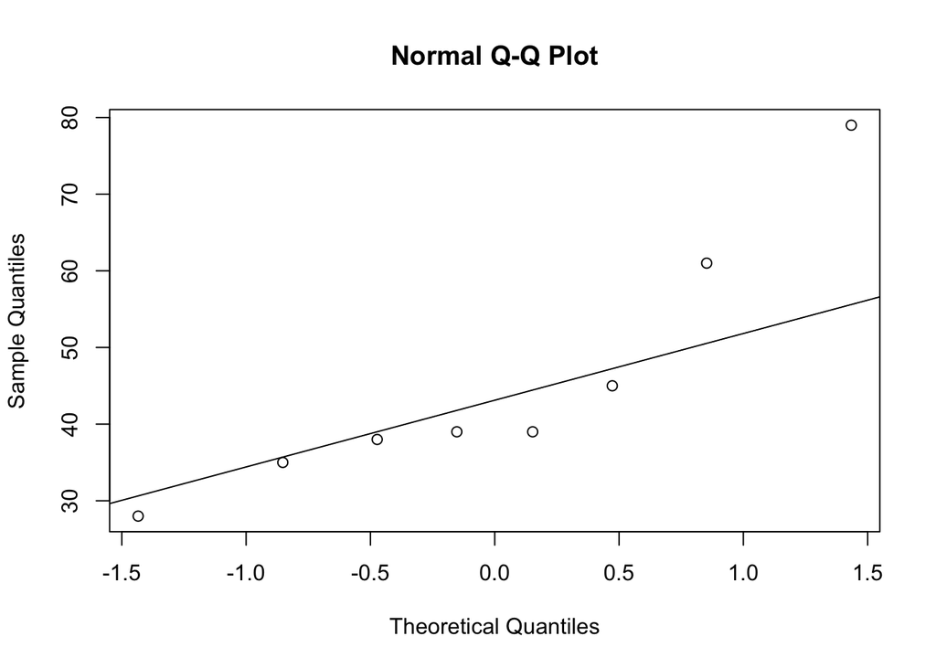

```r
# qqplots for BURROWS
# Produce a normal QQ plot of the values
qqnorm(greenDS$BURROWS) # assess observed/theoretical quantities for BURROWS
qqline(greenDS$BURROWS) # add the trend line
```

```r
# How strong is the relation between total biomass and burrows density changes for the Drum site?
cor(
  x = greenDS$BURROWS, # Sets the x-axes range of values
  y = greenDS$TOTMASS, # Sets the y-axes range of values
  method = "pearson"
)
```

```
## [1] 0.3917155
```

**Your task:**

Based on the data stored in the object `green` you will:

- Assess the correlation between total biomass (y-axis) per site and burrows density (x-axis) for the `LS` site.
- How strong is the relation between total biomass and burrows density changes for each site?

```r
# create an object with the observations for Lower site
greenLS <- green[green$SITE == "LS", ]

# Step 1. Test for assumptions of correlation, here two assumptions are checked which need to be fulfilled before performing the correlation.
shapiro.test(greenLS$TOTMASS) # assess normality for TOTMASS
```

```
##
##  Shapiro-Wilk normality test
##
## data:  greenLS$TOTMASS
## W = 0.8053, p-value = 0.01682
```

```r
shapiro.test(greenLS$BURROWS) # assess normality for BURROWS
```

```
##
##  Shapiro-Wilk normality test
##
## data:  greenLS$BURROWS
## W = 0.91282, p-value = 0.3009
```

```r
# Are the variables normally distributed?
## Here 'TOTMASS p–value is lower than 0.05, so we can not assume the normality for all variables.

# Step 2 Estimate the Pearson and Spearman correlations
## Pearson Correlation
cor(
  x = greenLS$BURROWS, # Sets the x-axes range of values
  y = greenLS$TOTMASS, # Sets the y-axes range of values
  method = "pearson"
) # Sets the correlation coefficient to use
```

```
## [1] 0.8819549
```

```r
## Spearman Correlation
cor(
  x = greenLS$BURROWS, # Sets the x-axes range of values
  y = greenLS$TOTMASS, # Sets the y-axes range of values
  method = "spearman"
) # Sets the correlation coefficient to use
```

```
## [1] 0.8510678
```

```r
# Based on the normality test which correlation coefficient you should use?
## As both TOTMASS are NOT normal for the Lower site spearman corrections should be used.

# How strong is the relation between total biomass and burrows density changes for the Lower site?
cor(
  x = greenLS$BURROWS, # Sets the x-axes range of values
  y = greenLS$TOTMASS, # Sets the y-axes range of values
  method = "spearman"
) # Sets the correlation coefficient to use
```

```
## [1] 0.8510678
```

## How “strong” is the covariation? - 1

The test you have done so far only estimate the strength of the relation, but what about the significance of the relation? for this you will use the `cor.test` function.

By using this approach you are now able to say more than if there is a positive/negative correlation between the variables. Now you can say if this relation is larger or samller than you would expect based on a theoretical distribution.

**Your task:**

Based on the data stored in the object `green` you will:

- Assess the significance of the correlation between total biomass (y-axis) per site and burrows density (x-axis) for `DS` and `LS` sites
- Are the relations significant?

```r
# create an object with the observations for Drumsite
greenDS <- green[green$SITE == "DS", ]

# Estimate the Pearson/Spearman correlations and it's significance - USE THE RIGTH TEST
cor.test(
  x = greenDS$BURROWS, # Sets the x-axes range of values
  y = greenDS$TOTMASS, # Sets the y-axes range of values
  method = "pearson"
) # Sets the correlation coefficient to use
```

```
##
##  Pearson's product-moment correlation
##
## data:  greenDS$BURROWS and greenDS$TOTMASS
## t = 1.0428, df = 6, p-value = 0.3372
## alternative hypothesis: true correlation is not equal to 0
## 95 percent confidence interval:
##  -0.4322803  0.8592175
## sample estimates:
##       cor
## 0.3917155
```

```r
# Is the relations significant?
## No because the p-value is larger than 0.05

# create an object with the observations for Lower site
greenLS <- green[green$SITE == "LS", ]

# Estimate the Pearson/Spearman correlations and it's significance - USE THE RIGTH TEST
cor.test(
  x = greenLS$BURROWS, # Sets the x-axes range of values
  y = greenLS$TOTMASS, # Sets the y-axes range of values
  exact = F,
  method = "spearman"
) # Sets the correlation coefficient to use
```

```
##
##  Spearman's rank correlation rho
##
## data:  greenLS$BURROWS and greenLS$TOTMASS
## S = 24.574, p-value = 0.001791
## alternative hypothesis: true rho is not equal to 0
## sample estimates:
##       rho
## 0.8510678
```

```r
# Is the relations significant?
## Yes because the p-value is lower than 0.05
```

## Plotting residuals and identifying outliers

In exploratory work, you want to look beyond the obvious relationship between variables by examining the observations deviating from the general straight-line pattern. You can look into this by considering the **residuals**, which are the differences between the observed Biomass and the values predicted from the fitted resistant line.

Positive residual values correspond to observed values that are larger than the values predicted from the straight-line relation, and negative residuals correspond to observed values smaller than the predicted rates.

The set of residuals are stored in the list element `ResLn$residuals` that we created when building the scatter-plots. The `plot` function can then be used to construct a scatterplot of residuals against the burrows density. By adding a horizontal line to this plot, is then easy to assess trends in the residual variation, and possible outliers.

**Your task:**

Based on the data stored in the object `green` you will:

- Plot the residuals of the `TOTMASS` vs. `BURROWS` relation for the Drum (`DS`) site only.
- Identify possible outliers.

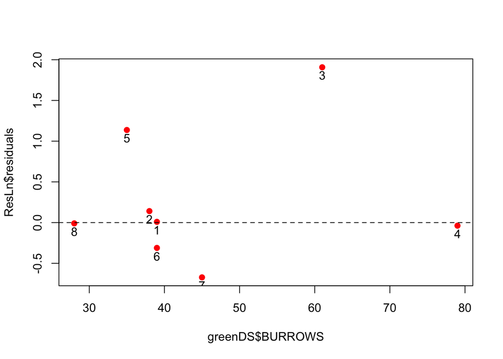

```r
# Create an object with the observations for Drumsite
greenDS <- green[green$SITE == "DS", ]

# Create a resistance line object
ResLn <- line(
  x = greenDS$BURROWS, ## The x-axis variable
  y = greenDS$TOTMASS
) ## The y-axis variable

# Plot the Residuals vs BURROWS
plot(
  x = greenDS$BURROWS, # The BURROWS values for the DS site
  y = ResLn$residuals, # the residuals of the TOTMASS ~ BURROWS relations for DS sites
  pch = 19, # Make the points a fill circle
  col = "red"
) # Make The points red

# Add a horizontal dashed line
abline(
  h = 0, # set the value for the horizontal line
  lty = 2
) # make the line dashed

# Add the quadrant number to each dot
text(
  x = greenDS$BURROWS, # The BURROWS values for the DS site
  y = ResLn$residuals - 0.1, # the residuals of the TOTMASS ~ BURROWS relations for DS sites
  # substract 0.1 so the name is below each point
  labels = greenDS$QUADNUM
)
```

```r
# Identify possible outliers.
## Quadrants 5 and 3 are possible outliers.
```

## Final Thoughts

Exploratory data analysis is the process by which a person manipulates data with the goal of learning about general patterns or tendencies and finding specific occurrences that deviate from the general patterns. Much like a detective explores a crime scene, collects evidence and draws conclusions, a statistician explores data using graphical displays and suitable summaries to draw conclusions about the main message of the data.

Here you have taken the first steps in this direction by describing the variation in the data, assessing the differences between groups, and establishing the relations between variables.